# Clean code

Yineng Chen

7/21/2020

# Task 2 - Exploratory Data Analysis

## Load Data

```r
fileName="./data/en_US/en_US.blogs.txt"
con=file(fileName,open="r")
lineBlogs=readLines(con，encoding = "UTF-8")
close(con)

con = file("./data/en_US/en_US.twitter.txt")
linetwitter = readLines(con,skipNul = TRUE，encoding = "UTF-8")
close(con)


con = file("./data/en_US/en_US.news.txt")
linenews = readLines(con,skipNul = TRUE，encoding = "UTF-8")
close(con)

# all_read = readtext("./data/en_US/*.txt",
                # dvsep = "_",
                 # docvarsfrom = "filenames",
                 #   docvarnames = c("language","resource"))
```

## Construct corpus separetly

```r
# sentance as unit
# blogs
blogs_crop = corpus(lineBlogs)

# twitter
twitter_crop = corpus(linetwitter)

# news
news_crop = corpus(linenews)

# all_crop = corpus(all_read)
```

## Take sample

Construct a function to take random sample

```r
randomSampleCorp <- function(corp, p=0.01) {
        n1 <- ndoc(corp) # get number of docs
        n <- n1*p # get % random sample from total sentences
        corp_samp <- corpus_sample(corp, n, replace = FALSE)
        return(corp_samp)
}
```

Apply the function

```r
set.seed(1110)

blogs_samplecorp = randomSampleCorp(blogs_crop, p=0.01)
twitter_samplecorp = randomSampleCorp(twitter_crop, p=0.01)
news_samplecorp = randomSampleCorp(news_crop, p=0.01)
```

```r
# a function to name each sentance
idsentances = function(crop,source){
  docvars(crop, field = "id") <- c(1:ndoc(crop))
  docvars(crop, field = "source") <- c(as.character(source))
  # change document names
  docid <- paste(crop$source,
               crop$id,
                sep = " ")
  docnames(crop) <- docid
  crop
}
```

combind corporas

```r
blogs_samplecorp = idsentances(blogs_samplecorp,"blogs")
twitter_samplecorp = idsentances(twitter_samplecorp,"twitter")
news_samplecorp = idsentances(news_samplecorp,"news")

sample_crop = c(blogs_samplecorp,twitter_samplecorp,news_samplecorp)

sample_crop = corpus_reshape(sample_crop, to = 'sentences')
blogs_samplecorp = corpus_reshape(blogs_samplecorp, to = 'sentences')
twitter_samplecorp = corpus_reshape(twitter_samplecorp, to = 'sentences')
news_samplecorp = corpus_reshape(news_samplecorp, to = 'sentences')
```

## summary of sample corpus

```r
# Summarize
summ = data.frame(Document = c("Blogs","Twitter","News"),
              Sentences = c(ndoc(blogs_samplecorp),
              ndoc(twitter_samplecorp),
              ndoc(news_samplecorp)),
              Size = c(format(object.size(blogs_samplecorp), "GB", digits = 4),
             format(object.size(twitter_samplecorp), "GB", digits = 4),
             format(object.size(news_samplecorp), "GB", digits = 4))
)

knitr::kable(summ, caption = "Summary description of the sample English corpus")
```

Summary description of the sample English corpus

| Document | Sentences | Size |
| --- | --- | --- |
| Blogs | 23857 | 0.0078 Gb |
| Twitter | 37814 | 0.0113 Gb |
| News | 1577 | 6e-04 Gb |

## Clean sentances

Construct a function to clean sentances:

It is modified based on the code on [this] http://amunategui.github.io/speak-like-a-doctor/ webside.

```r
Clean_Sentences <- function(text_blob) {
        # swap all sentence ends with code 'ootoo'
        text_blob <- gsub(pattern=';|\\.|!|\\?', x=text_blob, replacement='ootoo')

        # remove all non-alpha text (numbers etc)
        text_blob <- gsub(pattern="[^[:alpha:]]", x=text_blob, replacement = ' ')
        # remove Non-English Words
       text_blob <- iconv(text_blob,"latin1","ASCII",sub = "")

        # force all characters to lower case
        text_blob <- tolower(text_blob)

        # remove any small words {size} or {min,max}
        text_blob <- gsub(pattern="\\W*\\b\\w{1,2}\\b", x=text_blob, replacement=' ')

        # Restore instances of e.g. "can't" when not appropriately converted
        text_blob <- gsub("\u0092", "'", text_blob)
        text_blob <- gsub("\u0093|\u0094", "", text_blob)

         # To avoid the conversion of e.g. "U.S."" to "us"
        text_blob <- gsub(pattern="U.S.A.| U.S.A | U.S | U.S.| U S | U.S | u s | u.s | u.s.a |united states |United States", x=text_blob, replacement='USA')

        # remove contiguous spaces
        text_blob <- gsub(pattern = "\\s+", x=text_blob, replacement=' ')

        # split sentences by split code
        sentence_vector <- unlist(strsplit(x=text_blob, split='ootoo',fixed = TRUE))
        return(sentence_vector)
}
```

clean sentance in sample_corp

```r
sample_crop_clean_sentences = Clean_Sentences(paste(sample_crop, collapse = " "))
sample_crop_clean = corpus(sample_crop_clean_sentences)
```

## Create a English dictionary

```r
dic_Url = "https://raw.githubusercontent.com/dwyl/english-words/master/words_alpha.txt"
download.file(dic_Url, destfile = "./dictionary/words_alpha.txt")

dictEn = read.csv(file = "./dictionary/words_alpha.txt", header = FALSE, sep = ",", stringsAsFactors = FALSE)

mydict = dictionary(list(engwords = dictEn[,1]))
```

Is it a quanteda dictionary?

```r
is.dictionary(mydict)
```

```
## [1] TRUE
```

# Tokens

```r
options(width = 110)
# tokens , remove numbers, punctuations and symbols

sample_tokens = tokens(sample_crop_clean,
                       remove_punct = TRUE,
                       remove_numbers = TRUE,
                       remove_symbols = TRUE)
```

Remove non-english words according to the dictionay

```r
sample_tokens = tokens_select(sample_tokens,
                              pattern = mydict,
                              selection = "keep",
                              case_insensitive = TRUE)
```

## what are the distributions of word frequencies?

### 1 gram

```r
# creat document feature matrix
sample_dfm_1g <- dfm(sample_tokens,remove = stopwords("english"), stem = TRUE)
# ndoc(sample_dfm_1g)
# nfeat(sample_dfm_1g)
topfeatures(sample_dfm_1g, 15)
```

```
##   can  like  just   get   one  time  love   day  make  good thank  know   now   see  work
##  2642  2589  2488  2460  2233  1973  1873  1847  1610  1581  1540  1531  1452  1360  1346
```

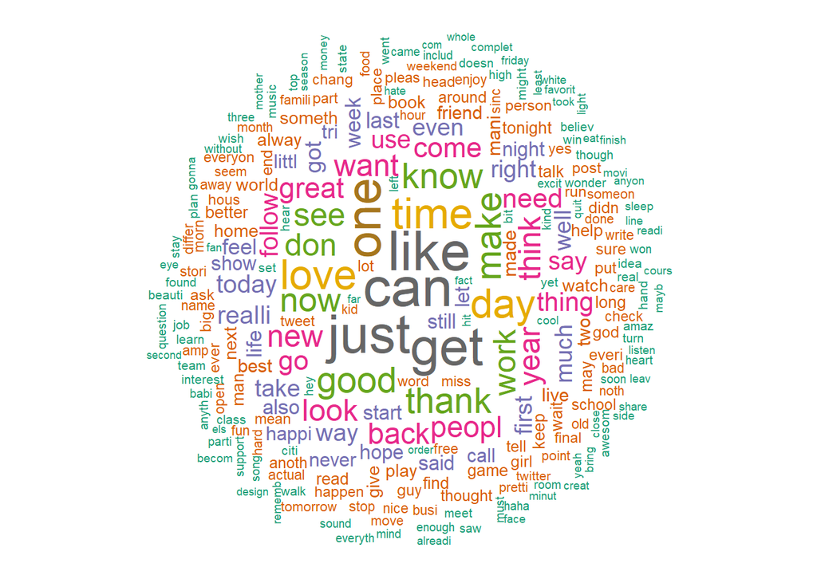

```r
# select : minimum character = 5
# sample_dfm_long <- dfm_select(sample_dfm, min_nchar = 5)
# top15_1g = topfeatures(sample_dfm_long, 15)  # top 10
# top15_1g

# word cloud for 1 gram
textplot_wordcloud(sample_dfm_1g , min_count = 230, random_order = FALSE,
                   rotation = .25,
                   colors = RColorBrewer::brewer.pal(8,"Dark2"))
```

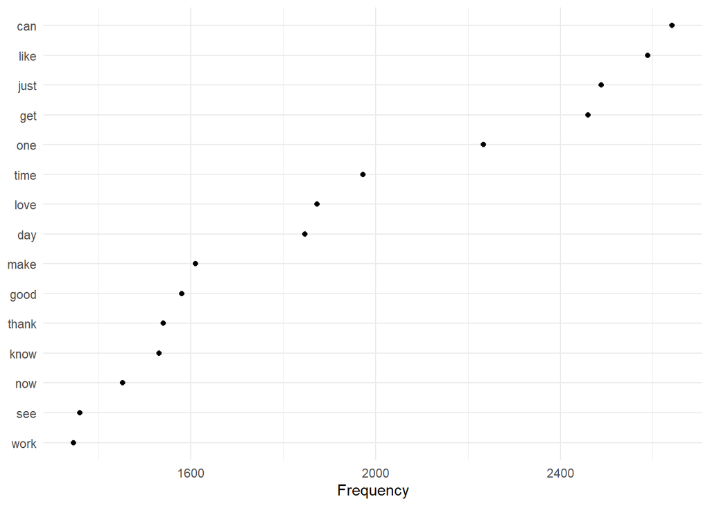

```r
sample_dfm_1g %>%
  textstat_frequency(n = 15) %>%
  ggplot(aes(x = reorder(feature, frequency), y = frequency)) +
  geom_point() +
  coord_flip() +
  labs(x = NULL, y = "Frequency") +
  theme_minimal()
```

## What are the frequencies of 2-grams and 3-grams in the dataset?

### Top 15 2-grams

```r
tokens_2gram  <- tokens_ngrams(sample_tokens, n = 2)
# head(tokens_2gram[[1]], 20)

# creat document feature matrix
sample_dfm_2g <- dfm(tokens_2gram,remove = stopwords("english"), stem = TRUE)
# ndoc(sample_dfm_2g)
# nfeat(sample_dfm_2g)
# sample_dfm_2g[,1:4]


top15_2g = topfeatures(sample_dfm_2g, 15)
top15_2g
```

```
##   for_the   and_the  with_the  from_the   all_the  that_the thank_for   you_can thank_you   you_are  you_have
##      1361       910       667       541       534       520       478       426       408       395       373
## the_first  the_same   out_the  the_best
##       344       321       320       320
```

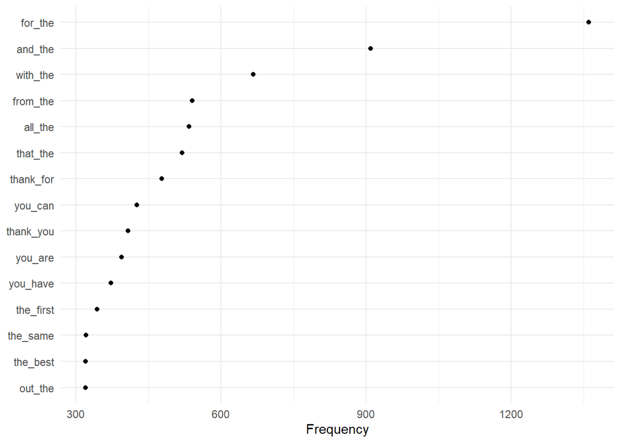

```r
sample_dfm_2g %>%
  textstat_frequency(n = 15) %>%
  ggplot(aes(x = reorder(feature, frequency), y = frequency)) +
  geom_point() +
  coord_flip() +
  labs(x = NULL, y = "Frequency") +
  theme_minimal()
```

```r
tokens_3gram  <- tokens_ngrams(sample_tokens, n = 3)
# head(tokens_3gram[[1]], 20)


# creat document feature matrix
sample_dfm_3g <- dfm(tokens_3gram,remove = stopwords("english"), stem = TRUE)
# ndoc(sample_dfm_3g)
# nfeat(sample_dfm_3g)
# sample_dfm_3g,1:4]


top15_3g = topfeatures(sample_dfm_3g, 15)
top15_3g
```

```
##  thank_for_the  thank_you_for for_the_follow  the_fact_that the_first_time    the_end_the   the_rest_the
##            243            106             89             77             64             59             57
##  for_the_first   all_the_time    for_all_the    how_are_you what_you_think thank_you_much   can_wait_for
##             52             46             45             41             41             39             34
##   wait_for_the
##             34
```

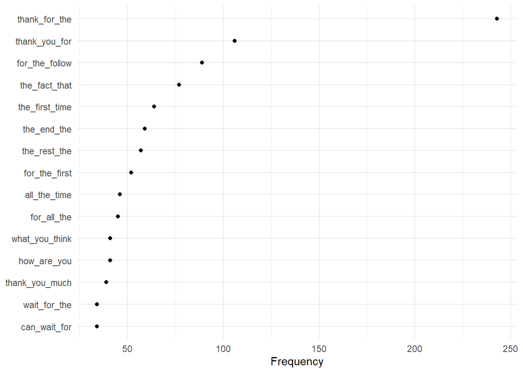

```r
sample_dfm_3g %>%
  textstat_frequency(n = 15) %>%
  ggplot(aes(x = reorder(feature, frequency), y = frequency)) +
  geom_point() +
  coord_flip() +
  labs(x = NULL, y = "Frequency") +
  theme_minimal()
```

## How many unique words do you need in a frequency sorted dictionary to cover 50%

```r
dfm_token_all <- dfm(sample_tokens, stem = TRUE)

# get frequency of each words
fre = textstat_frequency(dfm_token_all)

# total number of words
totalfreq = sum(fre$frequency) # 522724

sumCover = 0
maxlimt = length(fre$frequency)  # number of unique words 17047

for(i in 1: maxlimt) {
  sumCover <- sumCover + fre$frequency[i]
  if(sumCover >= 0.5*totalfreq){break}
}
print(i) # 172
```

```
## [1] 172
```

```r
sumCover = 0
maxlimt = length(fre$frequency)
for(i in 1: maxlimt) {
  sumCover <- sumCover + fre$frequency[i]
  if(sumCover >= 0.9*totalfreq){break}
}
print(i) # 2868
```

```
## [1] 2866
```

# A Prediction Model

## Training and testing data set

The sample data were seperated into training data and testing data at a ratio of 8 : 2 for each document.

```r
# construct corpus seperatly
## blog
blog_crop = corpus_reshape(blogs_samplecorp, to = 'sentences')

docvars(blog_crop, field = "num_sentance")= c(1:ndoc(blog_crop))

n = ndoc(blog_crop)
n_train = round(0.8*n)

train_blog = corpus_subset(blog_crop, num_sentance %in% c(1:n_train))
test_blogs = corpus_subset(blog_crop, num_sentance %in% c(n_train + 1:n))


## news
news_crop = corpus_reshape(news_samplecorp, to = 'sentences')

docvars(news_crop, field = "num_sentance") = c(1:ndoc(news_crop))

n = ndoc(news_crop)
n_train = round(0.8*n)

train_news = corpus_subset(news_crop, num_sentance %in% c(1:n_train))
test_news = corpus_subset(news_crop, num_sentance %in% c(n_train + 1:n))

## twitter
twitter_crop = corpus_reshape(twitter_samplecorp, to = 'sentences')

docvars(twitter_crop, field = "num_sentance") <- c(1:ndoc(twitter_crop))

n = ndoc(twitter_crop)
n_train = round(0.8*n)

train_twitter = corpus_subset(twitter_crop, num_sentance %in% c(1:n_train))
test_twitter = corpus_subset(twitter_crop, num_sentance %in% c(n_train + 1:n))


## Combine three corous
training = c(train_blog,train_news,train_twitter)
length(training) # 50568
```

```
## [1] 50599
```

```r
testing = c(test_blogs,test_news,test_twitter)
length(testing) # 12642
```

```
## [1] 12649
```

```r
rm("train_blog","train_news","train_twitter")
rm("test_blogs","test_news","test_twitter")
```

Apply the Clean_Sentences() function

```r
train_clean_sentences <- Clean_Sentences(paste(training, collapse = " "))
text_clean_sentences <- Clean_Sentences(paste(testing, collapse = " "))


## remove " "
train_clean_sentences <- train_clean_sentences[train_clean_sentences != ""]
text_clean_sentences <- text_clean_sentences[text_clean_sentences != ""]
```

See some of the sentances

```r
train_clean_sentences[1:3]
```

```
## [1] "heat pan medium high heat with about oil covering the bottom the pan"
## [2] " moisten the pork cubes with water then toss with the coating mix large plastic bag"
## [3] " add the pork the heated oil and let cook through turning get both sides golden brown"
```

```r
text_clean_sentences[1:3]
```

```
## [1] " for this reason that don like the character much"
## [2] " the books chronicle constant struggle between thomas and the people the land"
## [3] " them convince him become what meant become and save them from destruction"
```

## get n gram

### A function to get n garm

```r
# returns string w/o leading or trailing whitespace
trim <- function(x) gsub("^\\s+|\\s+$", "", x)


# a function to get n garm
Get_Ngrams <- function(sentence_splits, ngram_size=2) {
        ngrams <- c()
        for (sentence in sentence_splits) {
                sentence <- trim(sentence)
                if ((nchar(sentence) > 0) && (sapply(gregexpr("\\W+", sentence), length) >= ngram_size)) {
                        ngs <- ngram(sentence , n=ngram_size)
                        ngrams <- c(ngrams, get.ngrams(ngs))
                }
        }
        return(ngrams)
}
```

```r
n2 <- Get_Ngrams(train_clean_sentences, ngram_size = 2)
n3 <- Get_Ngrams(train_clean_sentences, ngram_size = 3)
n4 <- Get_Ngrams(train_clean_sentences, ngram_size = 4)
n5 <- Get_Ngrams(train_clean_sentences, ngram_size = 5)

n_all <- c(n2, n3, n4, n5)

write.csv(n_all, 'ngrams.csv', row.names = FALSE)

# n_all = read.csv("ngrams.csv")
```

## Anfunction to Predict

```r
next_word <- function(known_word){

  word = trim(known_word)

  if (nchar(word) == 0)
    return('')

  # find grams that match key words
  matches <- c()
  for (sentence in n_all) {
        # find exact match with double backslash and escape
        if (grepl(paste0('\\<',word), sentence)) {
                matches = c(matches, sentence)
                }
    }


  # didn't find a match so return nothing
 if (is.null(matches))
  return ('')


  # extract the second part after key words in all matches
  next_part_match <- c()
  for (a_match in matches) {
       next_part_match <- c(next_part_match,
                             strsplit(x = a_match, split = word)[[1]][[2]])
       next_part_match = trim(next_part_match)
    }

  # split second part by spaces and pick first word
  next_word_match = c()
    for (a_part in next_part_match){
    if (str_count(a_part, '\\w+') == 1){
      next_word_match <- c(next_word_match,a_part)
    } else {
      next_word_match <- c(next_word_match,
                             strsplit(x = a_part, split = " ")[[1]][[1]])
      }
    }

 # count the frequency of all next words
 word_count = aggregate(data.frame(count = next_word_match),
                        list(value = next_word_match), length)

 # find the word appear most frequently
 word_maxcount = word_count$value[word_count$count == max(word_count$count)]



  # return first word
  return(word_maxcount)

}

# known_word = "infection in patients"
# next_word("patients")
```